## Incarceration Data Visualization

By: Ryan Friesz

This report uses data analysis and visualization to expose how incarceration in the United States disproportionately effects people of color. This report will analyze data about how many people of color are incarcerated, the ratio compared to other races, and changes over time and locations in the United States to report on the injustice.

### Variable 1

The state in the US with the highest number of black people incarcerated in jail.

```r
highest_state_black_incarcerated
```

```
## [1] "CA"
```

### Variable 2

Percentage of total Latino population in jail in 2018

```r
total_percent_latino_population_jail
```

```
## [1] 0.002907913
```

### Variable 3

Percentage of total black population in jail in 2018

```r
total_percent_black_population_jail
```

```
## [1] 0.008761061
```

### Variable 4

Percentage of total white population in jail in 2018

```r
total_percent_white_population_jail
```

```
## [1] 0.002762605
```

### Variable 5

The urbanicity with the highest total jail population

```r
urbanicity_highest_incarceration
```

```
## [1] "urban"
```

# Chart 1: White population in jail from 2001 to 2010

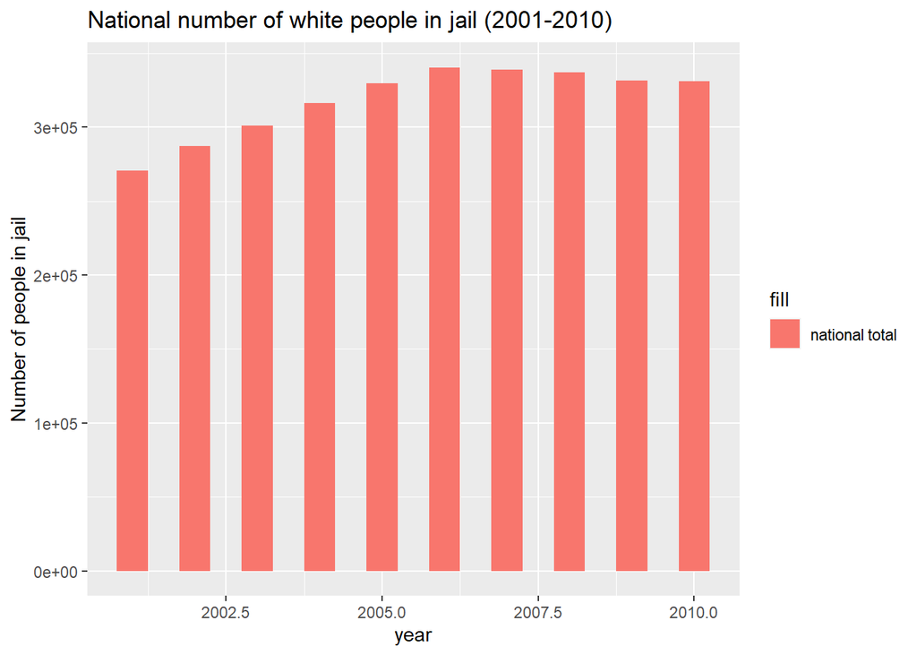

```r
chart_1
```

# Chart 2: Total white population and total black population in jail from 2000 to 2010

The year is on the x axis and the number of people in jail is on the y axis. The graph shows how starting in 2000 the number of white and black people in jail was relatively equal, and from there the difference grows. By 2006 that is the biggest difference in white jail population versus black jail population. While this graph does show that there are more white people in jail, it is important to keep in mind that there are many more white people in the US than there are black people. The graph was designed this way to make it easy to notice the difference in rates at which the population of white people in jail changed in comparison to the population of black people in jail. I was surprised to see that the rate of white people in jail increased at a faster rate from 2000 to 2006, but it is important to note how much smaller the total black population of the USA is.

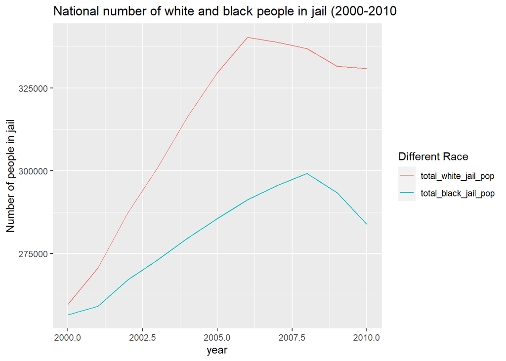

```r
chart_2
```

# Map

The map depicts how many time greater the proportion of black people in jail out of the total black population is to the proportion of white people in jail out of the total white population. The map shows that the state with the greatest difference is Minnesota, where in 2012 there were over 11 times the proportion of black people in jail compared compared to white people in jail. I designed the map because I think it gets to an important question, which is in what parts of the country is the inequity in incarceration the worst. I was surprise to see that Washington state was equally as bad as most southern states. California also surprised me because the amount of times larger the proportion of black people in jail to white people in jail was one of the largest out of all the states.

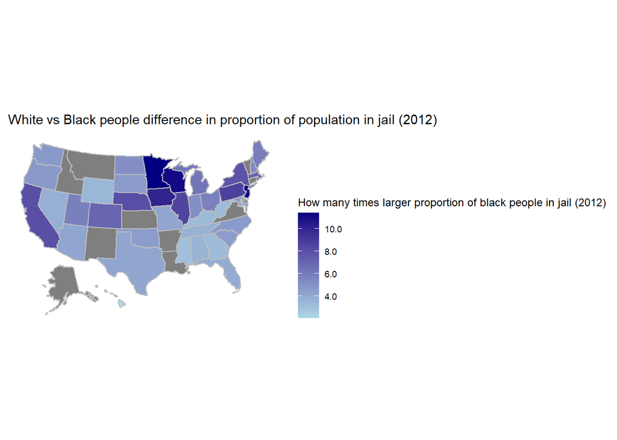

```r
map_1
```